# 02 — Analysis report (Deliverable B)

All tasks use the cleaned, joined table `master_train.csv` (Deliverable A): 82,742 zone-hours, 1 Jan – 31 Oct 2025, Addis local time.

**Comparison baseline used in B2 and B3.** "Expected" demand for a zone-hour = mean trips for the **same zone, month, weekday and hour** over *normal* hours: dry (observed weather, 0 mm), not a public holiday, and no event within ±6 h in that zone. Matching on month removes the Jan→Oct growth trend, which would otherwise make rainy-season hours look busier.

### Setup

```
(82742, 42) 2025-01-01 00:00:00 -> 2025-10-31 23:00:00
```

### Zone types (used in B1.2 and by notebooks 03 and 04)

Zones are grouped by the **shape** of their weekday hourly profile (each zone's curve divided by its own mean) with k-means; k is chosen by silhouette score. Names are given afterwards from each group's weekday peak hour and weekend ratio. Saved to `zone_types.csv`.

[output not shown]

```
silhouette by k: {2: np.float64(0.541), 3: np.float64(0.624), 4: np.float64(0.631), 5: np.float64(0.751), 6: np.float64(0.623)} -> k = 5
```

| zone | cluster | peak_hour | weekend_ratio | zone_type |
| --- | --- | --- | --- | --- |
| Piassa | 2 | 18 | 0.472 | Business / office (weekday commute) |
| Arat Kilo | 2 | 18 | 0.472 | Business / office (weekday commute) |
| Kazanchis | 2 | 18 | 0.485 | Business / office (weekday commute) |
| Bole | 4 | 6 | 1.344 | Leisure / nightlife (late, weekend-heavy) |
| Merkato | 1 | 13 | 0.880 | Market (midday peak) |
| Megenagna | 3 | 18 | 0.809 | Mixed hub (commute + busy midday) |
| Lideta | 3 | 18 | 0.815 | Mixed hub (commute + busy midday) |
| Ayat | 0 | 7 | 1.055 | Residential (evening peak, weekend >= weekday) |
| Kolfe | 0 | 7 | 1.076 | Residential (evening peak, weekend >= weekday) |
| CMC | 0 | 7 | 1.081 | Residential (evening peak, weekend >= weekday) |
| Sarbet | 0 | 7 | 1.086 | Residential (evening peak, weekend >= weekday) |
| Gerji | 0 | 7 | 1.090 | Residential (evening peak, weekend >= weekday) |

```
normal hours: 80.0% of rows | expected available for 99.1% of rows
```

## B1 — Demand patterns

### B1.1 Volume by zone

| zone | total_trips | zone_hours | mean_per_zone_hour | share_pct | first_day |
| --- | --- | --- | --- | --- | --- |
| Merkato | 283912 | 7010 | 40.5 | 12.1 | 01 Jan |
| Bole | 276178 | 7037 | 39.2 | 11.7 | 01 Jan |
| Megenagna | 268948 | 7034 | 38.2 | 11.4 | 01 Jan |
| Kazanchis | 223162 | 7034 | 31.7 | 9.5 | 01 Jan |
| Piassa | 199012 | 7044 | 28.3 | 8.5 | 01 Jan |
| Lideta | 197503 | 7052 | 28.0 | 8.4 | 01 Jan |
| CMC | 181736 | 7060 | 25.7 | 7.7 | 01 Jan |
| Gerji | 169922 | 7024 | 24.2 | 7.2 | 01 Jan |
| Kolfe | 161461 | 7039 | 22.9 | 6.9 | 01 Jan |
| Sarbet | 152368 | 7036 | 21.7 | 6.5 | 01 Jan |
| Arat Kilo | 144052 | 7039 | 20.5 | 6.1 | 01 Jan |
| Ayat | 95117 | 5333 | 17.8 | 4.0 | 15 Mar |

**Interpretation.** Merkato (12.1% of trips), Bole (11.7%) and Megenagna (11.4%) carry the most demand, each averaging about 38–41 trips per zone-hour; together they are over a third of the city. Ayat only started on 15 March, so its 4.0% share of total trips understates it — compare zones on mean trips per zone-hour (Ayat 17.8, the lowest, over about 1,700 fewer hours).

### B1.2 Hour-of-day profile by zone type (weekdays)

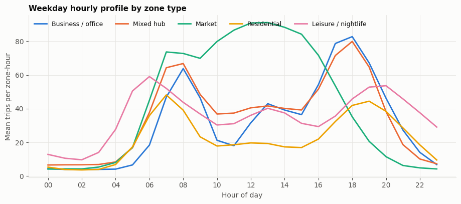

| zone_type | zones | morning peak | afternoon/evening peak | quietest | peak ÷ quietest |
| --- | --- | --- | --- | --- | --- |
| Business / office | Arat Kilo, Kazanchis, Piassa | 08:00 (64) | 18:00 (83) | 02:00 (3.9) | 21.4 |
| Mixed hub | Lideta, Megenagna | 08:00 (67) | 18:00 (80) | 00:00 (6.6) | 12.1 |
| Market | Merkato | 11:00 (87) | 13:00 (91) | 00:00 (4.2) | 21.8 |
| Residential | Ayat, CMC, Gerji, Kolfe, Sarbet | 07:00 (48) | 19:00 (44) | 02:00 (3.7) | 13.2 |
| Leisure / nightlife | Bole | 06:00 (59) | 20:00 (54) | 02:00 (9.7) | 6.1 |

### B1.3 Weekday vs weekend

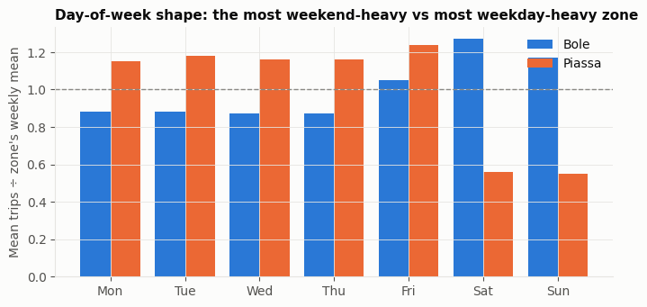

```
         Mon   Tue   Wed   Thu   Fri   Sat   Sun
zone
Bole    0.88  0.88  0.87  0.87  1.05  1.27  1.17
Piassa  1.15  1.18  1.16  1.16  1.24  0.56  0.55
```

| zone | zone type | weekday mean | weekend mean | weekend ÷ weekday |
| --- | --- | --- | --- | --- |
| Piassa | Business / office | 33.84 | 15.96 | 0.47 |
| Arat Kilo | Business / office | 24.54 | 11.59 | 0.47 |
| Kazanchis | Business / office | 37.85 | 18.34 | 0.48 |
| Megenagna | Mixed hub | 40.67 | 32.91 | 0.81 |
| Lideta | Mixed hub | 29.78 | 24.27 | 0.81 |
| Merkato | Market | 42.80 | 37.65 | 0.88 |
| Ayat | Residential | 17.54 | 18.49 | 1.05 |
| Kolfe | Residential | 22.43 | 24.14 | 1.08 |
| CMC | Residential | 25.15 | 27.18 | 1.08 |
| Sarbet | Residential | 21.15 | 22.96 | 1.09 |
| Gerji | Residential | 23.57 | 25.69 | 1.09 |
| Bole | Leisure / nightlife | 35.54 | 47.78 | 1.34 |

**Interpretation.** Business zones collapse at weekends to about 0.47× their weekday demand, Merkato and the mixed hubs dip moderately (0.81–0.88×), residential zones are slightly busier at weekends (1.05–1.09×), and Bole is 34% busier (1.34×). Bole stands out: Monday–Thursday run at 0.87–0.88 of its weekly mean, Friday rises to 1.05 and Saturday peaks at 1.27 — the mirror image of Piassa, which falls from 1.15–1.24 on weekdays to 0.55 at weekends.

### B1.4 Trend

```
11 zones open all year, weekly trips (scaled to full coverage): first 4 full weeks 44,534/week -> last 4 62,046/week = +39.3%
linear trend: +517 trips per week, every week (+0.96% of an average week)
all 12 zones, last full week (2025-10-20/2025-10-26): 63,768 trips
straight-line extrapolation: first two weeks of November ≈ 63,338 trips/week for the 11 zones
```

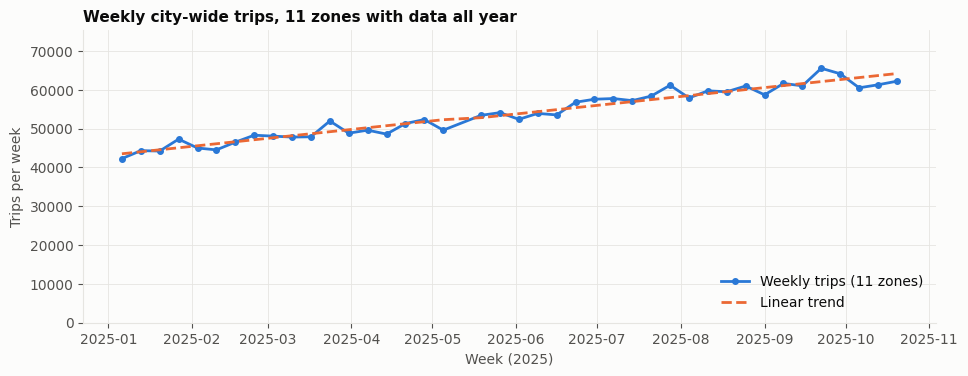

**Interpretation.** City demand grew steadily: the 11 zones with data all year went from about 44,500 trips per week in January to about 62,000 in October (+39%), a straight-line gain of about 517 trips per week, every week. A November forecast should therefore sit at or slightly above late-October levels (about 63,000 trips per week for those 11 zones), not at the January–October average; a model without a trend or recent-level feature would under-forecast.

## B2 — Weather

### B2.1 Timezone check

```
temperature peaks at 12:00 on the raw clock and 15:00 after +3 h (minimum 00:00 raw vs 03:00 corrected)
```

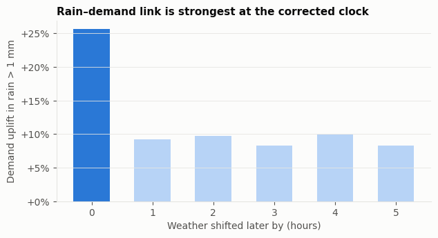

| shift (h) | rainy-hour demand ratio | corr(rain_mm, trips ÷ expected) |
| --- | --- | --- |
| 0 | 1.256 | 0.246 |
| 1 | 1.092 | 0.051 |
| 2 | 1.097 | 0.055 |
| 3 | 1.083 | 0.041 |
| 4 | 1.099 | 0.040 |
| 5 | 1.083 | 0.029 |

**Interpretation.** Weather timestamps are UTC: on the raw clock temperature peaks at 12:00 and bottoms at 00:00, which is solar noon and midnight in UTC; after +3 h it peaks at 15:00 and bottoms at 03:00, as expected in Addis. The rain–demand link is sharp only on the corrected clock: rainy hours (> 1 mm) run 26% above normal with the clocks aligned, but only 8–10% when weather is shifted by 1–5 hours, and the correlation drops from 0.25 to 0.03–0.06. A 3-hour clock error would have hidden most of the rain effect.

### B2.2 Rain effect by zone type

```
ratio by zone: {'Merkato': 0.781, 'Megenagna': 1.251, 'Gerji': 1.258, 'Lideta': 1.261, 'CMC': 1.264, 'Bole': 1.264, 'Piassa': 1.265, 'Kazanchis': 1.27, 'Arat Kilo': 1.275, 'Sarbet': 1.281, 'Kolfe': 1.288, 'Ayat': 1.296}
```

| zone_type | trips | expected | ratio | rainy zone-hours |
| --- | --- | --- | --- | --- |
| Business / office | 70759 | 55741.917 | 1.269 | 1323 |
| Mixed hub | 56765 | 45230.917 | 1.255 | 942 |
| Market | 20831 | 26662.833 | 0.781 | 471 |
| Residential | 87901 | 68925.250 | 1.275 | 2308 |
| Leisure / nightlife | 19168 | 15164.500 | 1.264 | 360 |

**Interpretation.** No — rain raises demand in 11 of 12 zones by a remarkably similar 25–30% versus the same zone, month, weekday and hour in dry weather, but Merkato drops to 0.78×. A market is an outdoor destination: rain cancels the trip rather than replacing walking with a ride.

### B2.3 Rain dose-response

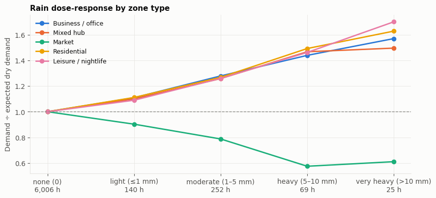

| rain_class zone_type | none (0) | light (≤1 mm) | moderate (1–5 mm) | heavy (5–10 mm) | very heavy (>10 mm) |
| --- | --- | --- | --- | --- | --- |
| Business / office | 1.0 | 1.109 | 1.279 | 1.439 | 1.570 |
| Mixed hub | 1.0 | 1.100 | 1.258 | 1.467 | 1.496 |
| Market | 1.0 | 0.903 | 0.788 | 0.575 | 0.610 |
| Residential | 1.0 | 1.111 | 1.268 | 1.493 | 1.628 |
| Leisure / nightlife | 1.0 | 1.089 | 1.260 | 1.462 | 1.701 |

**Interpretation.** The response is not proportional to rainfall. Demand rises steeply at first (+10% in light rain, +26–28% in 1–5 mm, +44–49% in 5–10 mm) and then flattens: above 10 mm the mixed hubs barely move further (1.47 → 1.50) and business zones add only another 13 points, while Bole and residential zones keep climbing to 1.63–1.70. Merkato falls in the opposite direction and bottoms out around 0.58–0.61 at heavy rain. A rain-class feature captures this better than raw millimetres.

## B3 — Events & calendar

### B3.1 Public holidays

```
                     holiday       date weekday  city index
0                Good Friday 2025-04-18     Fri        72.9
1                      Genna 2025-01-07     Tue        75.4
2      Patriots' Victory Day 2025-05-05     Mon        75.5
3                Eid al-Adha 2025-06-06     Fri        77.6
4                     Mawlid 2025-09-04     Thu        81.0
5                Eid al-Fitr 2025-03-31     Mon        82.5
6       Downfall of the Derg 2025-05-28     Wed        82.7
7                 Enkutatash 2025-09-11     Thu        83.6
8   International Labour Day 2025-05-01     Thu        85.0
9                     Meskel 2025-09-27     Sat        96.7
10                    Fasika 2025-04-20     Sun        97.8
11                    Timkat 2025-01-19     Sun       101.3
12          Adwa Victory Day 2025-03-02     Sun       104.5

mean holiday index by zone (weekday holidays only):
Piassa        46.8
Arat Kilo     47.6
Kazanchis     48.5
Merkato       52.3
Lideta        80.4
Megenagna     84.0
Sarbet       105.3
CMC          107.7
Gerji        108.5
Kolfe        108.9
Ayat         112.6
Bole         127.3
```

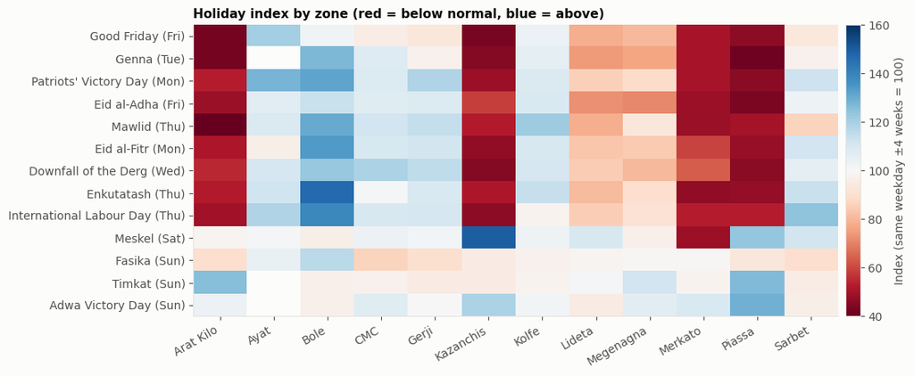

**Interpretation.** Every holiday that falls on a weekday cuts city demand to 73–85% of the same weekday in nearby weeks (Good Friday lowest at 73%); the four weekend holidays (Meskel on a Saturday; Fasika, Timkat and Adwa on Sundays) are within ±5% of a normal weekend day, so not all holidays reduce demand. The reaction is local: on weekday holidays the business zones and Merkato fall to about half (Piassa 47, Arat Kilo 48, Kazanchis 49, Merkato 52), the mixed hubs dip to 80–84, while residential zones rise 5–13% and Bole rises 27% — people stay home or go out instead of commuting.

### B3.2 Event-window study (football)

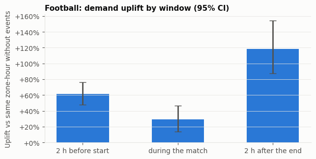

| window | matches | mean ratio | median ratio | 95% CI low | 95% CI high |
| --- | --- | --- | --- | --- | --- |
| 2 h before start | 32 | 1.616 | 1.645 | 1.476 | 1.761 |
| during the match | 35 | 1.291 | 1.141 | 1.139 | 1.464 |
| 2 h after the end | 35 | 2.183 | 1.952 | 1.874 | 2.544 |

**Interpretation.** The largest uplift is after the match: in the 2 hours after the end, demand in the stadium zone is 2.2× a normal zone-hour (95% CI 1.9–2.5), versus 1.6× in the 2 hours before kick-off and only 1.3× during the match (the median during is 1.14). Crowds arrive spread out but all leave at once, so the post-match exit surge is the window to staff for.

### B3.3 Event type ranking

| event type | events | effect (ratio) | 95% CI low | 95% CI high | measurable? |
| --- | --- | --- | --- | --- | --- |
| football_match | 36 | 1.723 | 1.554 | 1.898 | yes |
| concert | 25 | 1.261 | 1.214 | 1.307 | yes |
| conference | 35 | 1.201 | 1.127 | 1.275 | yes |
| exhibition | 7 | 1.007 | 0.964 | 1.039 | no |
| sports_run | 2 | 0.844 | NaN | NaN | too few events |
| road_closure | 25 | 0.789 | 0.738 | 0.838 | yes |

**Interpretation.** Football matches have the largest effect (1.72× over the window from 2 h before to 2 h after), followed by concerts (1.26×) and conferences (1.20×); all three are clearly measurable. Road closures reduce demand to 0.79× in the closed zone. Exhibitions show no measurable effect (1.01×, CI 0.96–1.04): spread over several days, their visitors do not concentrate in any hour. Sports runs (2 events, 0.84×) are too few to judge.

### B3.4 Cancelled and unlisted events

```
cancelled events, actual ÷ expected over [start − 2 h, end + 2 h):
event_id                  event_name      zone               start  ratio active event overlapping
EVT-0020        Premier league match Kazanchis 2025-02-22 15:00:00   1.61  EVT-0021 football_match
EVT-0042 Conference: Health congress Kazanchis 2025-04-03 08:00:00   0.94                     none
EVT-0052        Premier league match Kazanchis 2025-04-23 18:00:00   1.11                     none
EVT-0058        Premier league match Kazanchis 2025-05-03 15:00:00   0.91                     none
EVT-0099                Live concert      Bole 2025-07-28 20:00:00   1.14    EVT-0096 school_break
EVT-0113                Live concert      Bole 2025-09-01 20:00:00   1.14         EVT-0114 concert

for reference, 95% of normal zone-hours have a ratio between 0.62 and 1.57
```

| pickup_hour | zones | n_zones | extra_trips |
| --- | --- | --- | --- |
| Tue 30 Sep 2025 14:00 | Kazanchis, Megenagna, Piassa, Sarbet | 4 | 197.0 |
| Mon 23 Jun 2025 19:00 | Bole, Gerji | 2 | 84.0 |
| Sat 26 Jul 2025 16:00 | Gerji, Sarbet | 2 | 66.0 |
| Fri 12 Sep 2025 16:00 | Megenagna | 1 | 45.0 |
| Sun 27 Apr 2025 18:00 | Lideta, Piassa | 2 | 43.0 |
| Wed 03 Sep 2025 07:00 | Lideta | 1 | 38.0 |
| Tue 29 Apr 2025 21:00 | Ayat, Piassa | 2 | 37.0 |
| Mon 06 Jan 2025 18:00 | Merkato | 1 | 36.0 |

## B4 — Operations & data quality

### B4.1 Operational variables vs demand

```
trips per active driver: median 1.31
```

|  | Pearson r | Spearman ρ | Pearson r within zone × hour |
| --- | --- | --- | --- |
| active_drivers | 0.987 | 0.993 | 0.961 |
| avg_wait_min | 0.535 | 0.641 | 0.229 |
| avg_fare_birr | 0.006 | 0.072 | 0.176 |

**Interpretation.** Trips correlate almost perfectly with active_drivers (r = 0.99, still 0.96 within the same zone and hour) and moderately with avg_wait_min (0.54), while avg_fare_birr is unrelated (0.01). These correlations describe the same hour, not cause and effect: more drivers come online because demand is high, and waits lengthen when demand outpaces drivers. None of the three is known when forecasting days ahead — using them would leak the answer (D4: RMSE 3.2 with them vs 9.0 without), so they are excluded as inputs.

### B4.2 Gaps and outages

```
outage: 12 May 02:00 – 13 May 19:00 (42 consecutive hours)
random-gap lengths (excluding the outage): {1: 2416, 2: 66, 3: 2}
```

| kind | zone-hours | treatment |
| --- | --- | --- |
| random missing record / blank target | 2192 | left missing; no target to learn from |
| platform outage (all 12 zones missing) | 504 | left missing; not imputed; lags across it are ... |
| removed in cleaning: conflicting duplicates | 362 | excluded from training (no trusted target) |
| zone not launched yet (Ayat before 15 Mar) | 1752 | not counted as missing; Ayat modelled only fro... |

**Interpretation.** The history has no rows for 3,058 zone-hours of launched zones plus 1,752 Ayat hours before launch. Genuine outage: 12 May 02:00 – 13 May 19:00, 42 consecutive hours missing in all 12 zones at once (504 zone-hours). Not launched: Ayat before 15 March (not counted as missing). Random: 2,192 scattered records (mostly single hours, never more than 3 in a row) plus 362 zone-hours removed in cleaning as conflicting duplicates. None are imputed for the target; lags that fall on a gap are left missing.

### B4.3 Pay-period effect

```
payday uplift +5.9% (Welch t = 10.1, p = 3.9e-17)
```

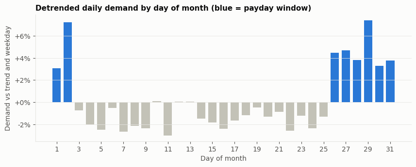

| period | mean | count |
| --- | --- | --- |
| ordinary day | 0.9849 | 214 |
| payday window (26th – 2nd) | 1.0431 | 75 |

**Interpretation.** Yes: after removing the trend and weekday effects, the payday window (26th to 2nd) runs 5.9% above ordinary days (Welch t = 10.1, p < 0.001), with the strongest days on the 29th and the 2nd. That is about 2 extra trips per zone-hour — smaller than the hour-of-day or rain effects but consistent and known in advance, so days_to_month_end is worth keeping as a feature.